# DV_RProject3

Monica and Rachel

October 12, 2015

## **Part 1 Extracting Data and Transforming into SQL Statement**

For our project, we extracted data from three different tables displaying education statistics from different A schools, Elementaries, Middle Schools, and High Schools in Colorado in 2011.

The first table displays the different schools and their varying Math, Reading, and Writing grades as well as their growth rates.

The code that we used to extract, transform, and load the data into an sql statement is as follows:

```r
source("../01 Data/ETL_1.R")
```

The second table we used displays the schools as well as the free and reduced lunches. The code we used is as follows:

```r
source("../01 Data/ELT_2.R")
```

The last table we used displays the schools as well as the different ethnic percentages. The code we used is as follows:

```r
source("../01 Data/ETL_3.R")
```

## **Part 2 Importing into SQL and creating dataframes**

Next, we used the SQL statement and imported the data into SQL. We then took the data from SQL and put them into dataframes in R using this code below:

```r
source("../02 Data Wrangling/Final Grades.R", echo = TRUE)
```

```
##
## > require("jsonlite")
##
## > require("RCurl")
##
## > final_grades <- data.frame(fromJSON(getURL(URLencode("129.152.144.84:5001/rest/native/?query=\"select * from FINAL_GRADE where SCHOOLNUMBER is not n .... [TRUNCATED]
##
## > summary(final_grades)
##                            SCHOOLNAME                 DISTRICTNAME
##  CENTENNIAL ELEMENTARY SCHOOL   :   5   DENVER COUNTY 1     : 193
##  COLUMBINE ELEMENTARY SCHOOL    :   5   JEFFERSON COUNTY R-1: 179
##  FRONTIER CHARTER ACADEMY       :   5   DOUGLAS COUNTY RE 1 :  91
##  LINCOLN ELEMENTARY SCHOOL      :   5   ADAMS-ARAPAHOE 28J  :  70
##  MESA ELEMENTARY SCHOOL         :   5   BOULDER VALLEY RE 2 :  64
##  MOUNTAIN VIEW ELEMENTARY SCHOOL:   5   COLORADO SPRINGS 11 :  63
##  (Other)                        :2039   (Other)             :1409
##  EMH      EMH_COMBINED                  INITIAL_PLANTYPE
##  A:  38   EMH :   6    Improvement Plan         :245
##  E:1089   MH  :  16    No CDE Plan Type         : 81
##  H: 426   null:2047    null                     :534
##  M: 516                Pending AEC SPF          : 73
##                        Performance Plan         :977
##                        Priority Improvement Plan:127
##                        Turnaround Plan          : 32
##                    FINAL_PLANTYPE
##  Performance Plan         :1038
##  null                     : 534
##  Improvement Plan         : 263
##  Priority Improvement Plan: 123
##  Turnaround Plan          :  38
##  AEC; Performance Plan    :  25
##  (Other)                  :  48
##                                                NOTES      DISTRICTNUMBER
##  Approved Request to Reconsider                   :   1   Min.   :  10
##  Deferred to district rating                      :  12   1st Qu.: 580
##  Denied Request to Reconsider                     :   3   Median :1040
##  Insufficient state evidence, deferred to district:  38   Mean   :1405
##  New school                                       :  36   3rd Qu.:1810
##  New school, deferred to district rating          :   7   Max.   :9130
##  null                                             :1972
```

[output cut: 171 more lines]

```
## > head(subset(k_12_frl, X_FREE_AND_REDUCED > 0.5))
##        DISTRICT_NAME                                           SCHOOL_NAME
## 1 ADAMS-ARAPAHOE 28J                           DARTMOUTH ELEMENTARY SCHOOL
## 2 ADAMS-ARAPAHOE 28J                                    EAST MIDDLE SCHOOL
## 3 ADAMS-ARAPAHOE 28J                             ELKHART ELEMENTARY SCHOOL
## 4 ADAMS-ARAPAHOE 28J FLETCHER INTERMEDIATE SCIENCE  and  TECHNOLOGY SCHOOL
## 5 ADAMS-ARAPAHOE 28J                               FLETCHER PRIMARY SCHOOL
## 6 ADAMS-ARAPAHOE 28J                              FULTON ELEMENTARY SCHOOL
##   DISTRICT_CODE SCHOOL_CODE X_FREE_AND_REDUCED
## 1           180        2114               57.4
## 2           180        2384               87.1
## 3           180        2618               94.6
## 4           180        2995               89.9
## 5           180        2998               92.7
## 6           180        3272               91.6
```

## **Part 3 Combining the three tables**

To combine the tables, we used the school code of each school as the primary key that connects the three tables together. We used the tables in different types of joins in each of the data sets we created below.

## **Part 4 Creating interesting graphics through data wrangling**

### **Data Set 1**

We joined all three of the data frames together for this data set. We did this by using an inner join by the unique school code, as it was a common factor in all three data frames. To wrangle the data, we selected the reading growth grade and math growth grades from the joined data set. We also selected EMH, which is an indicator of the level of school (elementary, middle, high school). We filtered out A schools because they did not have any data in these fields.

```r
source("../02 Data Wrangling/Set 1.R",echo = TRUE)
```

```
##
## > require(tidyr)
##
## > require(dplyr)
##
## > require(ggplot2)
##
## > require(jsonlite)
##
## > require(RCurl)
##
## > x <- final_grades %>% inner_join(., enrl_working,
## +     by = "SCHOOL_CODE", copy = TRUE) %>% inner_join(., k_12_frl,
## +     by = "SCHOOL_CODE", cop .... [TRUNCATED]
##
## > plot1 <- ggplot() + coord_cartesian() + scale_x_continuous(breaks = 1:15) +
## +     scale_y_continuous(breaks = 1:15) + labs(title = "Math Growth Sco ..." ... [TRUNCATED]
##
## > plot1
```

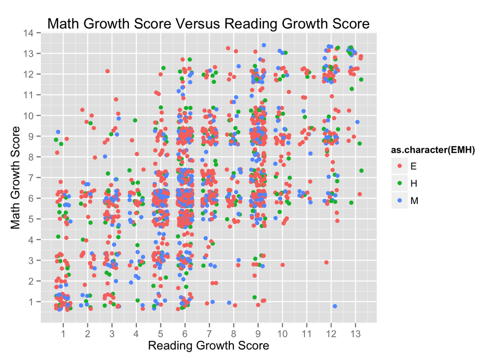

We noticed that there is a correlation between the two growth scores. However, by coloring for EMH, we noticed that there is no correlation between the growth of the different types of schools. That is to say that high schoolers are not learning at a faster rate than elementary schools - the distrubution is spread out, there are just a lot more elementary and middle schools.

### **Data Set 2**

For this dataset we joined all three data sets again, but added some more data wrangling in. This time we did a left join of the FRL and ENRL data sets by the school code column. We then mutated a column for the percentage of non-white students.

We compared the percentage of non-white students against the percentage of students that recieved the Free/Reduced meal plan. We also colored by the school’s project plan. From this we can see a couple of interesting things. The Performance plan is by far the most popular in elementary schools. However, as the percentage of non white students increases ther number of schools with the Turnaround Plan also increases. This can be seen to a lesser extent with middle schools as well. Also, we can see that there is indeed a correlation between percentage of non-white students and having free/reduced meal plans.

```r
source("../02 Data Wrangling/Set 2.R",echo = TRUE)
```

```
##
## > require(tidyr)
##
## > require(dplyr)
##
## > require(ggplot2)
##
## > require(jsonlite)
##
## > require(RCurl)
##
## > outer_join_df <- enrl_working %>% left_join(., k_12_frl,
## +     by = "SCHOOL_CODE", copy = TRUE) %>% right_join(., final_grades,
## +     by = "SCHOOL ..." ... [TRUNCATED]
##
## > plot2 <- ggplot() + coord_cartesian() + scale_x_continuous(labels = percent) +
## +     scale_y_continuous(labels = percent) + facet_grid(. ~ EMH) +
##  .... [TRUNCATED]
##
## > plot2
```

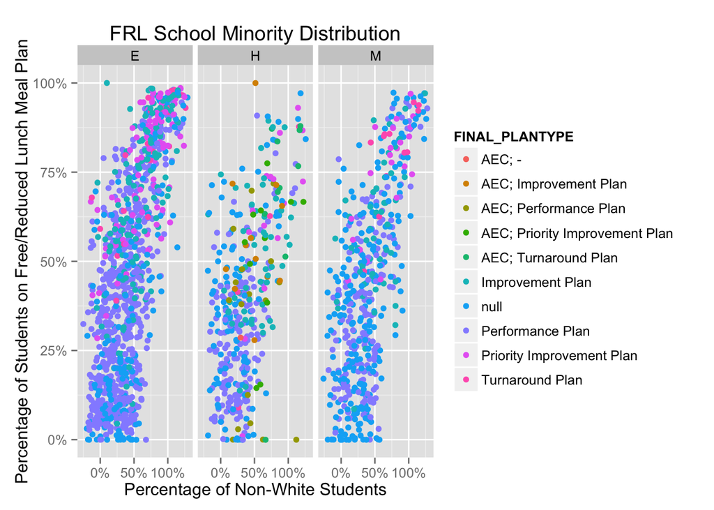

### **Data Set 3**

For this dataset we did a full join of the enrl and final grade data sets.

We compared the percentage of white students with the school’s success measured in two ways: ranking and overall achievement score. It is very clear to see that schools with a higher percentage of white students not only achieved higher scores, but were ranked much higher. There are a couple of interesting things to note. There are two schools with very large student bodies that have a high percentage of white students but were ranked very poorly and performed poorly as well. This indicates that perhaps having too large a school with limited resources affects the students’ ability to learn and achieve.

```r
source("../02 Data Wrangling/Set 3.R",echo = TRUE)
```

```
##
## > require(tidyr)
##
## > require(dplyr)
##
## > require(ggplot2)
##
## > require(jsonlite)
##
## > require(RCurl)
##
## > last_join_df <- final_grades %>% full_join(., enrl_working,
## +     by = "SCHOOL_CODE") %>% select(TOTAL, PCT_WHITE, DISTRICTNUMBER,
## +     OVERALL_A .... [TRUNCATED]
##
## > plot3 <- ggplot() + coord_cartesian() + scale_x_continuous() +
## +     scale_y_continuous(labels = percent) + labs(title = "Percentage of White Stude ..." ... [TRUNCATED]
##
## > plot3
```

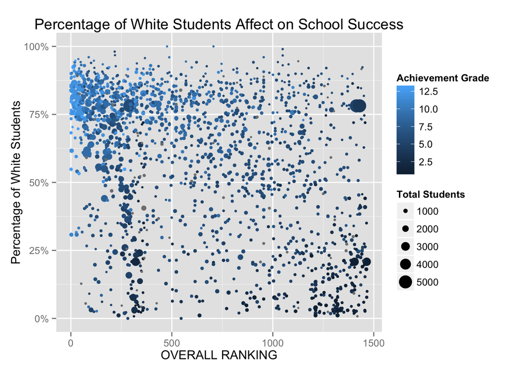